# Week 4: Points and Polygons

Carole Voulgaris

9/17/2020

I’ll be using the following libraries for this tutorial:

```r
library(sf)
library(tidyverse)
library(ggthemes)
library(ggspatial)
library(units)
library(nngeo)
```

## Loading the data

First, I’ll read in all four datasets from the Boston Open Data portal (refer to the [video tutorial](https://harvard.zoom.us/rec/share/bwcxR8_MCa8zDh0Wp07W9v8AF5kTSi3wVre_tbqeQkPP8P19BbgSWese-1NdlxQ.OjMA6BPxeSnwHNQ-?startTime=1600374226000) for how I got the urls to read from).

Notice that I’m setting `quite=TRUE` on each call of `st_read()` function to avoid having a bunch of progress messages clutter up my knitted html file.

```r
nhoods <- st_read("http://bostonopendata-boston.opendata.arcgis.com/datasets/3525b0ee6e6b427f9aab5d0a1d0a1a28_0.kml",
                  quiet = TRUE)

water <- st_read("http://bostonopendata-boston.opendata.arcgis.com/datasets/2b3c0fa13b1c468eb702a3645fcc6bcb_5.kml",
                 quiet = TRUE)

parking <- st_read("http://bostonopendata-boston.opendata.arcgis.com/datasets/962da9bb739f440ba33e746661921244_9.kml",
                   quiet = TRUE)

trees <- st_read("http://bostonopendata-boston.opendata.arcgis.com/datasets/ce863d38db284efe83555caf8a832e2a_1.kml",
                 quiet = TRUE)
```

## Transforming the data

I’ll be doing some distance and area calculations, so it’s important that my spatial data is stored using a projected coordinate system (i.e. with coordinates in feet or meters) rather than a geographic coordinate system (i.e. with coordinates in degrees latitude and longitude).

I’ll transform my data to the Massachusetts State Plane system (remember, you can find the PROJ4 strings for most coordinate systems at [spatialreference.org](https://spatialreference.org/)).

```r
MA_state_plane <- "+proj=lcc +lat_1=41.71666666666667 +lat_2=42.68333333333333 +lat_0=41 +lon_0=-71.5 +x_0=200000 +y_0=750000 +ellps=GRS80 +units=m +no_defs"

nhoods <- nhoods %>%
  st_transform(MA_state_plane)

water <- water %>%
  st_transform(MA_state_plane)

parking <- parking %>%
  st_transform(MA_state_plane)

trees <- trees %>%
  st_transform(MA_state_plane)
```

I’ll draw a quick map now to see how the data look.

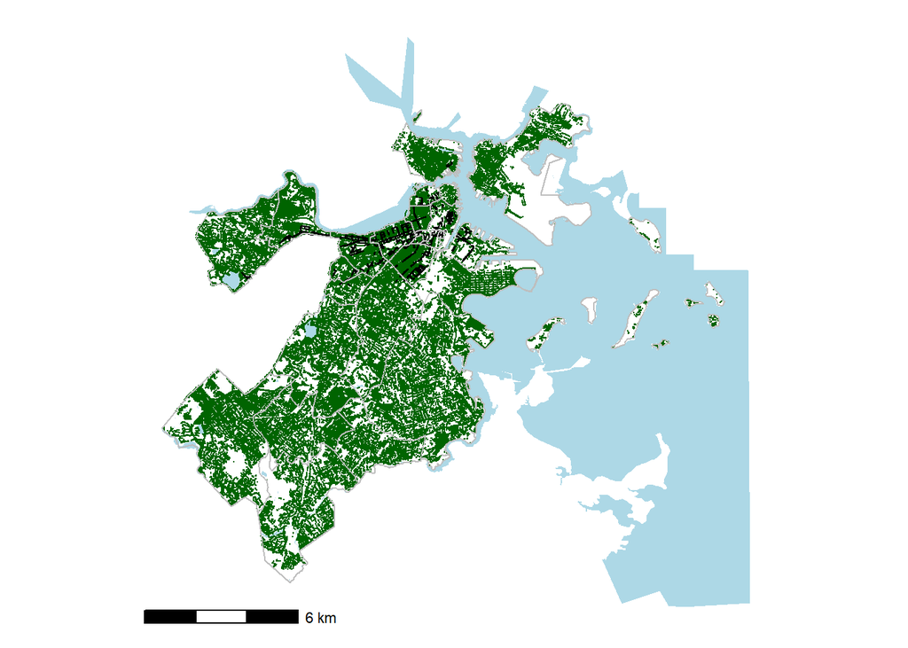

```r
ggplot(water) +
  geom_sf(fill = "lightblue", color = NA) +
  geom_sf(data = trees, color = "darkgreen", size = 0.01) +
  geom_sf(data = parking, size = 0.01) +
  geom_sf(data= nhoods, fill = NA, color = "gray") +
  theme_map() +
  annotation_scale()
```

## Creating a buffer

The Massachusetts State Plane coordinate system I’m using is in units of meters (notice that the PROJ4 string says `+units=m` towards the end), so any distance/area calculations I do will be in meters or square meters.

How many of the trees in Boston are within 30 meters of a parking meter?

To figure this out, I’ll create a new polygon layer to represent a 30-meter buffer around the parking meters. `st_buffer()` will create a circle around each parking meter, and I’m adding `st_union()` after that to dissolve the overlapping circles and combine them all into one multipolygon.

I’ll plot a quick map to see how the buffer looks.

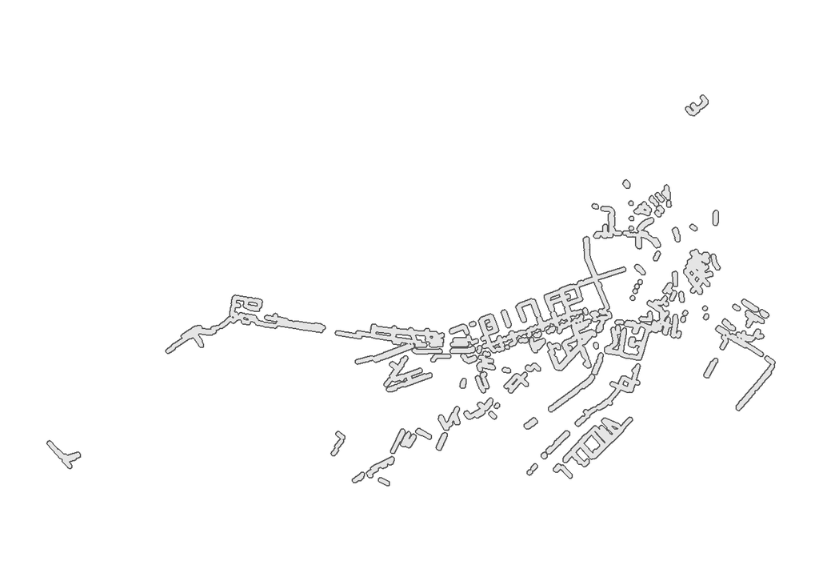

```r
parking_buffer <- st_buffer(parking, dist = 30) %>%
  st_union()

ggplot(parking_buffer) +
  geom_sf() +
  theme_map()
```

## Subsetting points with a polygon

Now I can create a dataframe that only includes the trees that are located within the parking meter buffer.

Then we can see how that subset of trees looks on the map. I’ll draw them on top of the parking meter buffer.

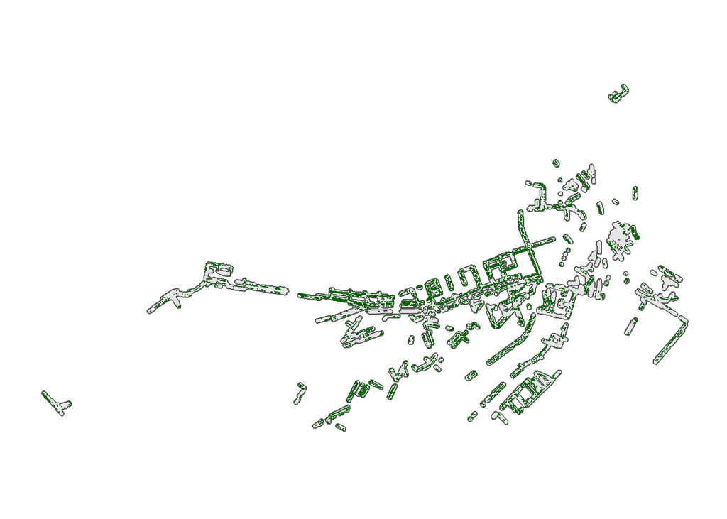

```r
trees_parking <- trees[parking_buffer,]

ggplot(parking_buffer) +
  geom_sf() +
  geom_sf(data = trees_parking,
          color = "darkgreen",
          size = 0.01) +
  theme_map()
```

Now I’ll join my two trees dataframes. For any trees that are in the `trees` dataset, but not in `trees_parking`, there will be an NA value for the variables `Name.y` and `Description.y`. Based on which values of `Name.y` are NA, I can create a binary variable that indicates whether each tree is by a parking meter.

```r
trees <- trees %>%
  st_join(trees_parking) %>%
  mutate(by_parking = !is.na(Name.y))
```

Now we can calculate how many trees are within 30 meters of a parking meter:

```r
n_parking_trees <- sum(trees$by_parking)

n_parking_trees
```

```
## [1] 7838
```

And what percent of all trees does this represent?

```r
n_trees <- length(trees$by_parking)

pct_parking_trees <- n_parking_trees / n_trees

pct_parking_trees
```

```
## [1] 0.03883139
```

About 4 percent of all trees in Boston are within 30 meters of a parking meter.

Let’s show this on a pretty map!

I’ll include a note about the number and percent of trees near parking, and I want to add that note to the top left corner of the map. To find the coordinates of the top left corner, I can use `st_bbox()` to get the extents of one of my layers (I’ll use the tree layer because it covers the most area).

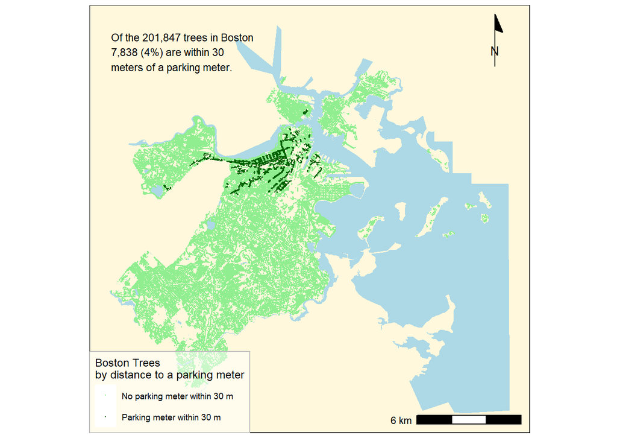

```r
left_side  <- st_bbox(trees)$xmin
top_side <- st_bbox(trees)$ymax

ggplot(water) +
  geom_sf(fill = "lightblue", color = NA) +
  geom_sf(data = trees, size = 0.01,
          aes(color = by_parking)) +
  scale_color_manual(values = c("lightgreen", "darkgreen"),
          name = "Boston Trees\nby distance to a parking meter",
          labels = c("No parking meter within 30 m",
                     "Parking meter within 30 m")) +
  annotation_scale(location = "br") +
  annotation_north_arrow(location = "tr",
                         style = north_arrow_minimal()) +
  annotate(geom = "text", x = left_side,
           y = top_side,
           label = paste("Of the ",
                         prettyNum(n_trees, big.mark = ","),
                         " trees in Boston\n",
                         prettyNum(n_parking_trees, big.mark = ","),
                         " (",
                         prettyNum(100*pct_parking_trees, digits = 0),
                         "%) are within 30\nmeters of a parking meter.",
                         sep = ""),
           hjust = 0, vjust = 0, size = 3) +
  theme_map() +
  theme(panel.background = element_rect(fill = "cornsilk1"),
        legend.background = element_rect(fill = alpha("white", 0.5),
                                         color = "gray"))
```

## Counting points in a polygon

What if I wanted to know how many trees are in each Boston neighborhood?

`st_covers()` will return a list of the trees in each neighborhood. By using `lengths()` to get the length of each of those lists, I can get the number of trees in each neighborhood and add that as a column to my neighborhoods dataframe.

Then, I can use that new variable to make a chloropleth map.

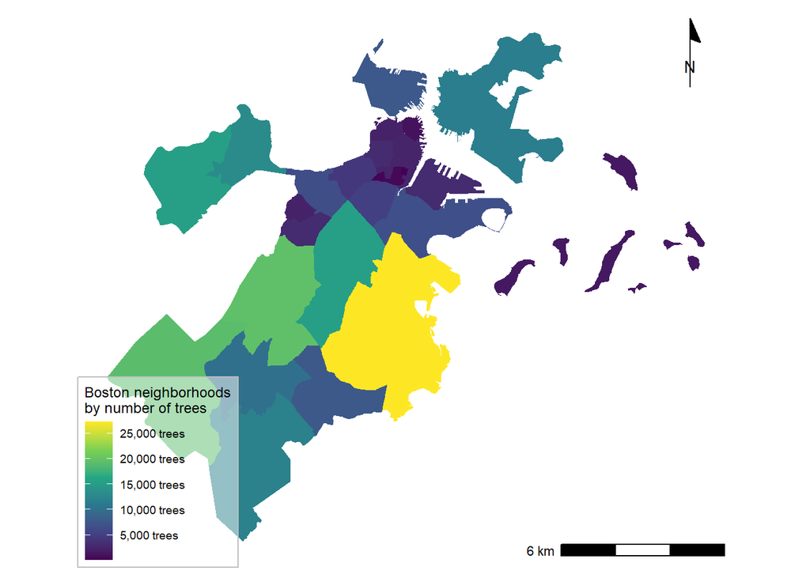

```r
nhoods <- nhoods %>%
  mutate(num_trees = lengths(st_covers(nhoods, trees)))

ggplot(nhoods) +
  geom_sf(color = NA,
          aes(fill = num_trees)) +
  scale_fill_viridis_c(name = "Boston neighborhoods\nby number of trees",
                       breaks = breaks <- seq(0, 30000, by = 5000),
                       labels = paste(prettyNum(breaks, big.mark = ","),
                                      "trees")) +
  annotation_scale(location = "br") +
  annotation_north_arrow(location = "tr",
                         style = north_arrow_minimal()) +
theme_map() +
  theme(legend.background = element_rect(fill = alpha("white", 0.5),
                                         color = "gray"))
```

## Calculating areas and densities

Maybe I’m more interested in the density of trees (the number of trees per square km). To calculate that, I’d need to find the area of each neighborhood using `st_area()`.

`st_area()` will calculate the areas in square meters because those are the units of the coordinate system we’re using. Square kilometers might be more useful, so I’ll use `set_units()` to convert from square meters to square kilometers.

The result will be a particular data type that includes units, which can trip up ggplot() when it creates the legend, so I’ll use `as.numeric()` to convert to just regular numbers.

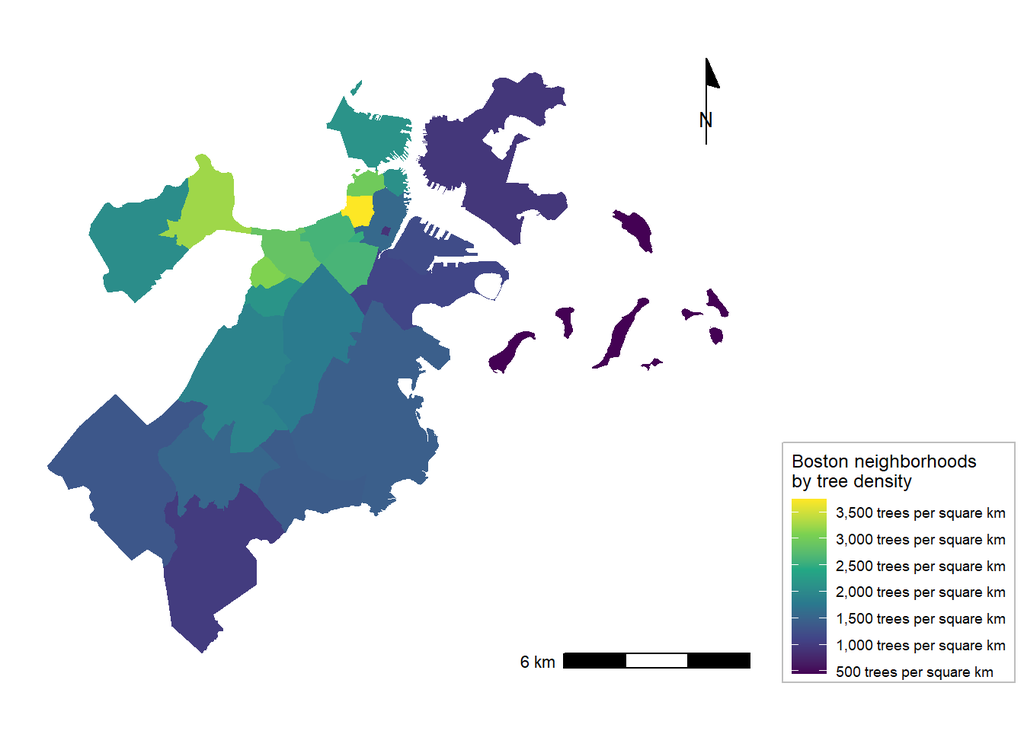

```r
nhoods <- nhoods %>%
  mutate(area = set_units(st_area(nhoods), km^2)) %>%
  mutate(tree_dens = as.numeric(num_trees / area))

ggplot(nhoods) +
  geom_sf(color = NA,
          aes(fill = tree_dens)) +
    scale_fill_viridis_c(name =
                           "Boston neighborhoods\nby tree density",
                       breaks = breaks <- seq(0, 4000, by = 500),
                       labels = paste(prettyNum(breaks, big.mark = ","),
                                      "trees per square km")) +
  annotation_scale(location = "br") +
  annotation_north_arrow(location = "tr",
                         style = north_arrow_minimal()) +
theme_map() +
  theme(legend.position = "right",
    legend.background = element_rect(fill = alpha("white", 0.5),
                                         color = "gray"))
```

## Finding the closest point

Maybe I want to know how far each parking meter is from a tree.

`st_nn()` will return the row number (from the trees dataframe) of the nearest tree and, if I set `returnDist=TRUE`, it will also return the distance to the closest tree. I don’t really care which tree it is (a tree is a tree, right?), so I’ll just use `st_nn()$dist` to get the distances.

It returns the distance in a weird format, so I’m adding a second mutate statement to make sure it’s treated as a number.

```r
parking <- parking %>%
  mutate(tree_dist = st_nn(parking, trees,
                           returnDist = TRUE)$dist) %>%
  mutate(tree_dist = as.numeric(tree_dist))
```

Now I can calculate the average distance from a parking meter to the nearest tree.

```r
avg_tree_dist <- mean(parking$tree_dist)

avg_tree_dist
```

```
## [1] 15.86701
```

And I can also create a map to represent how far each parking meter is from a tree. I’m using `coord_sf()` to set the map extents to just the area where the parking meters are.

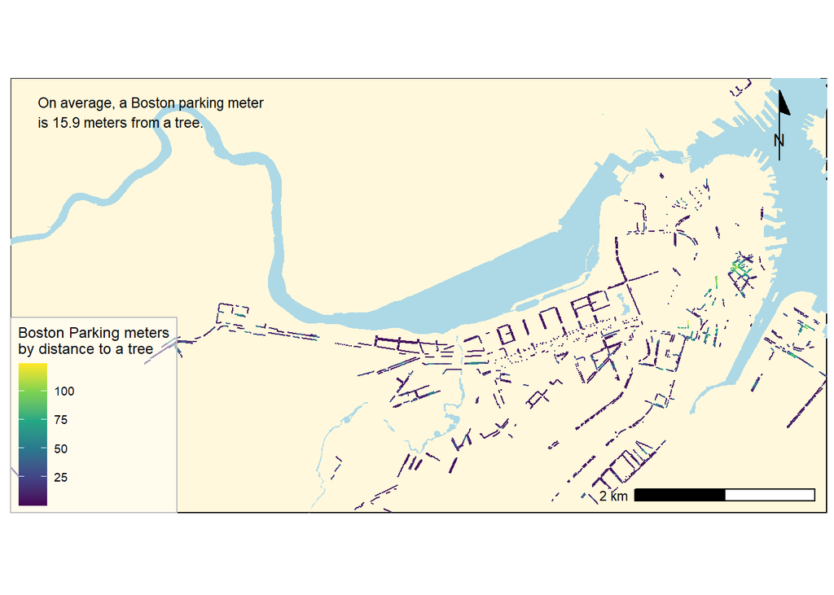

```r
right_side <- st_bbox(parking)$xmax
left_side  <- st_bbox(parking)$xmin
top_side <- st_bbox(parking)$ymax
bottom_side <- st_bbox(parking)$ymin


ggplot(water) +
  geom_sf(fill = "lightblue", color = NA) +
  geom_sf(data = parking, size = 0.1,
          aes(color = tree_dist)) +
  coord_sf(xlim = c(left_side, right_side),
           ylim = c(bottom_side, top_side), expand = FALSE) +
  scale_color_viridis_c(name =
                          "Boston Parking meters\nby distance to a tree") +
  annotation_scale(location = "br") +
  annotation_north_arrow(location = "tr",
                         style = north_arrow_minimal()) +
  annotate(geom = "text", x = left_side + 300,
           y = top_side - 550,
           label = paste("On average, a Boston parking meter\nis ",
                         prettyNum(avg_tree_dist, digits = 3),
                         " meters from a tree.",
                         sep = ""),
           hjust = 0, vjust = 0, size = 3) +
  theme_map() +
  theme(panel.background = element_rect(fill = "cornsilk1"),
        legend.background = element_rect(fill = alpha("white", 0.5),
                                         color = "gray"))
```

## Identifying overlapping polygons

Maybe I’d like to know which neighborhoods have bodies of water in them. `st_overlaps()` works the same as `st_covers()` but instead of telling me the number of features contained by each neighborhood, it tells me the number of features that overlaps each neighborhood.

```r
nhoods <- nhoods %>%
  mutate(num_water = lengths(st_overlaps(nhoods, water))) %>%
  mutate(has_water = num_water > 0)
```

How many neighborhoods overlap with bodies of water?

```r
n_water_nhoods <- sum(nhoods$has_water)

n_water_nhoods
```

```
## [1] 20
```

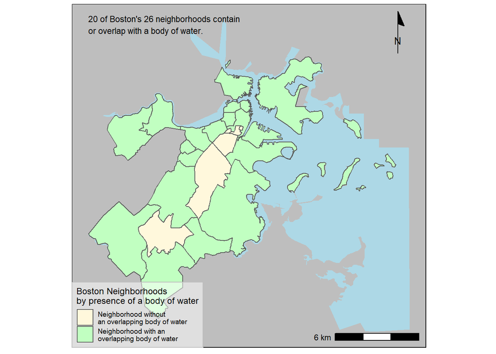

```r
left_side  <- st_bbox(water)$xmin
top_side <- st_bbox(water)$ymax

ggplot(water) +
  geom_sf(fill = "lightblue", color = NA) +
  geom_sf(data = nhoods,
          aes(fill = has_water)) +
  scale_fill_manual(values = c("cornsilk1", "darkseagreen1"),
          name = "Boston Neighborhoods\nby presence of a body of water",
          labels = c("Neighborhood without\nan overlapping body of water",
                     "Neighborhood with an\noverlapping body of water")) +
  annotation_scale(location = "br") +
  annotation_north_arrow(location = "tr",
                         style = north_arrow_minimal()) +
  annotate(geom = "text", x = left_side,
           y = top_side - 1000,
           label = paste(n_water_nhoods ,
                         "of Boston's",
                         length(nhoods$Name),
                         "neighborhoods contain\nor overlap with",
                         "a body of water."),
           hjust = 0, vjust = 0, size = 3) +
  theme_map() +
  theme(panel.background = element_rect(fill = "gray"),
        legend.background = element_rect(fill = alpha("white", 0.5),
                                         color = "gray"))
```